# Deeper analysis: symptom-specific heterogeneity, contrasts and robustness

**Research question.** Among self-reported actual-use reporter-drug pairs in the v2 probe, what symptom-specific outcome heterogeneity and adverse-event patterns are reported, and how robust are they to extraction and reporter clustering?

**Abstract.** Notebook 2 reports that helped directions dominate the extracted effect records overall. This notebook shows that they are **not uniform across symptom classes**: reporting of benefit is markedly lower for **nonspecific fatigue** than for mood/cognitive, most sharply under ketamine, and benefit-plus-harm and no-effect experiences remain visible throughout. **No post-exertional-malaise result is reported.** The v1 `energy_pem` class merged explicit PEM with ordinary fatigue and low energy under one pattern; separated out, explicit-PEM targets are too few to clear the evidence gate for any drug, so the fatigue finding is stated as a fatigue finding and nothing here is called PEM.

**The analysis unit is a Reddit account, not a verified person** (notebook 1, §1), and reader-facing counts are counts of accounts.

**This notebook reports no p-values and performs no hypothesis tests.** Every comparison is stated as a rate difference in percentage points with a reporter-clustered bootstrap interval and an effect size, ranked by magnitude and gated on a minimum evidence threshold (notebook 1, §9). **Each headline contrast moves one factor** — a symptom class against the same drug's other classes, or a drug against the other drugs inside the same class — rather than against an omnibus "rest of corpus" reference that changes drug, symptom, route and reporter mix at once; a drug-by-symptom interaction model is reported alongside. No equivalence test is performed either, so overlapping intervals are never described as showing that two drugs are the same. Adverse-event shares describe reports, not incidence. Route of administration is reported for ketamine only, as a **stated route** and not as an administration setting, which this run does not measure; LSD numeric dosing is reported as **insufficient data** rather than binned into a result. All conclusions remain hypothesis-generating because the cohort is selected, extraction is not human-validated, and no control arm exists. The practical recommendation is to treat symptom-specific and harm-aware reporting patterns as signals for validation, not as patient-specific treatment advice.

**This is one of three notebooks over the same pinned extraction run.**

|  | notebook | what it answers |
| --- | --- | --- |
| 1 | `psychedelics_v2_01_methods` | who is in the cohort, what the extractor did, and how well it did it |
| 2 | `psychedelics_v2_02_overview` | the headline descriptive picture: direction, magnitude, duration, adverse events, doses |
| 3 | `psychedelics_v2_03_deep_dive` | symptom-specific heterogeneity, contrasts, robustness, and what to validate first |

They share one loader and one setup cell, and every one of them is a description of extractable Reddit reporting patterns rather than a measurement of any drug.

```
included claims = self-reported actual use: 2,921 claims, 953 reporter-drug pairs
```

## 1. Symptom-specific outcome map

**The `energy_pem` composite is gone.** One regular expression matched `pem`, `fatigue`, `energy`, `tired`, `exhaust`, `crash`, `exertion`, `stamina` and `cfs`, and the result was reported as post-exertional malaise — so a report of ordinary tiredness was counted as evidence about PEM, a specific delayed worsening after exertion. The four constructs are now separate classes:

| class | what the target has to say |
| --- | --- |
| `pem_explicit` | post-exertional malaise or worsening, payback, crashing *after* activity |
| `exertion_intolerance` | exertion, exercise, stamina, endurance, activity tolerance, without stating post-exertional worsening |
| `fatigue_general` | fatigue, exhaustion, tiredness, malaise, or an ME/CFS diagnosis label |
| `low_energy` | low energy, sluggishness, listlessness |

`mood_cognitive` and `pain` are unchanged. `other` is a stated target that matches no class; `unspecified` is a target the extractor never stated.

**No result in this notebook is called PEM unless the target said post-exertional.** Under that rule every `pem_explicit` cell falls below the evidence gate for every drug, so this notebook reports **no PEM-specific result at all** — see the composition table immediately below.

**Classification is multilabel.** A target naming both brain fog and fatigue belongs to `mood_cognitive` *and* `fatigue_general`. The earlier rule returned on the first pattern that matched, so pattern order — not the text — decided which class such a record landed in, and fatigue-bearing targets were systematically pulled out of the energy classes. Membership is now recorded for every class a target matches. Where a single label is needed for display, it is the most specific match under a fixed precedence — explicit post-exertional worsening, then exertion, then pain, then mood/cognitive, then nonspecific fatigue, then bare low energy — an ordering by construct specificity that is defined in the loader and does not depend on any outcome. §1.3 reruns the headline contrast under multilabel assignment as a sensitivity check.

Each cell is shown with its row count, its reporter-account count, and a reporter-clustered bootstrap interval. Cells below the evidence gate (fewer than 20 rows or 10 reporter accounts) are marked `insufficient` and are excluded from every headline and every ranking in this notebook; they are displayed only so the reader can see how thin they are. Within a single drug-symptom cell each account contributes at most one row, so rows and accounts coincide there; clustering bites in the comparisons, where one account spans several symptom classes.

Multilabel columns count a record under every class it matches; exclusive columns use the single display label.

| symptom class | records (multilabel) | reporters (multilabel) | records (exclusive) | reporters (exclusive) |
| --- | --- | --- | --- | --- |
| pem_explicit | 41 | 19 | 41 | 19 |
| exertion_intolerance | 9 | 9 | 5 | 5 |
| pain | 197 | 107 | 197 | 107 |
| mood_cognitive | 730 | 303 | 703 | 297 |
| fatigue_general | 127 | 82 | 95 | 66 |
| low_energy | 67 | 49 | 48 | 36 |
| other | 833 | 292 | 833 | 292 |
| unspecified | 968 | 327 | 968 | 327 |

| classes matched | records | share |
| --- | --- | --- |
| 0 | 1,801 | 62.3% |
| 1 | 1,014 | 35.1% |
| 2 | 69 | 2.4% |
| 3 | 5 | 0.2% |
| 4 | 1 | 0.0% |

**Composition.** The retired `energy_pem` composite covered 244 effect records. Only 41 of them (19 reporter accounts) state post-exertional worsening; 127 state nonspecific fatigue. A class that is 17% explicit PEM should not be reported as a PEM result, which is why the composite is retired rather than renamed. Separately, 75 effect records match more than one symptom class; under the old single-label rule the class each of those landed in was decided by pattern order.

| drug | symptom class | direction | k | rows | patients | rate | 95% clustered CI | evidence |
| --- | --- | --- | --- | --- | --- | --- | --- | --- |
| ketamine | exertion_intolerance | helped | 1 | 2 | 2 | 50.0% | 0.0%–100.0% | insufficient |
| ketamine | fatigue_general | helped | 13 | 35 | 35 | 37.1% | 22.9%–54.3% | ok |
| ketamine | low_energy | helped | 11 | 16 | 16 | 68.8% | 43.8%–87.5% | insufficient |
| ketamine | mood_cognitive | helped | 136 | 155 | 155 | 87.7% | 82.6%–92.9% | ok |
| ketamine | other | helped | 112 | 130 | 130 | 86.2% | 80.0%–91.5% | ok |
| ketamine | pain | helped | 69 | 78 | 78 | 88.5% | 80.8%–94.9% | ok |
| ketamine | pem_explicit | helped | 7 | 9 | 9 | 77.8% | 44.4%–100.0% | insufficient |
| ketamine | unspecified | helped | 116 | 151 | 151 | 76.8% | 70.2%–82.8% | ok |
| lsd | exertion_intolerance | helped | 1 | 1 | 1 | 100.0% | — | insufficient |
| lsd | fatigue_general | helped | 6 | 9 | 9 | 66.7% | 33.3%–88.9% | insufficient |
| lsd | low_energy | helped | 4 | 5 | 5 | 80.0% | 40.0%–100.0% | insufficient |
| lsd | mood_cognitive | helped | 15 | 15 | 15 | 100.0% | 100.0%–100.0% | insufficient |
| lsd | other | helped | 24 | 27 | 27 | 88.9% | 77.8%–100.0% | ok |
| lsd | pain | helped | 3 | 4 | 4 | 75.0% | 25.0%–100.0% | insufficient |
| lsd | pem_explicit | helped | 1 | 1 | 1 | 100.0% | — | insufficient |
| lsd | unspecified | helped | 14 | 18 | 18 | 77.8% | 55.6%–94.4% | insufficient |
| psilocybin | exertion_intolerance | helped | 2 | 2 | 2 | 100.0% | 100.0%–100.0% | insufficient |
| psilocybin | fatigue_general | helped | 17 | 23 | 23 | 73.9% | 56.5%–91.3% | ok |
| psilocybin | low_energy | helped | 12 | 16 | 16 | 75.0% | 50.0%–93.8% | insufficient |
| psilocybin | mood_cognitive | helped | 122 | 131 | 131 | 93.1% | 88.5%–96.9% | ok |
| psilocybin | other | helped | 128 | 144 | 144 | 88.9% | 83.3%–93.8% | ok |
| psilocybin | pain | helped | 26 | 29 | 29 | 89.7% | 75.9%–100.0% | ok |
| psilocybin | pem_explicit | helped | 5 | 9 | 9 | 55.6% | 22.2%–88.9% | insufficient |
| psilocybin | unspecified | helped | 147 | 176 | 176 | 83.5% | 77.8%–88.6% | ok |
| ketamine | exertion_intolerance | worsened | 0 | 2 | 2 | 0.0% | 0.0%–0.0% | insufficient |
| ketamine | fatigue_general | worsened | 6 | 35 | 35 | 17.1% | 5.7%–31.4% | ok |
| ketamine | low_energy | worsened | 1 | 16 | 16 | 6.2% | 0.0%–18.8% | insufficient |
| ketamine | mood_cognitive | worsened | 11 | 155 | 155 | 7.1% | 3.2%–11.0% | ok |
| ketamine | other | worsened | 11 | 130 | 130 | 8.5% | 3.8%–13.1% | ok |
| ketamine | pain | worsened | 1 | 78 | 78 | 1.3% | 0.0%–3.8% | ok |
| ketamine | pem_explicit | worsened | 0 | 9 | 9 | 0.0% | 0.0%–0.0% | insufficient |
| ketamine | unspecified | worsened | 9 | 151 | 151 | 6.0% | 2.6%–9.9% | ok |
| lsd | exertion_intolerance | worsened | 0 | 1 | 1 | 0.0% | — | insufficient |
| lsd | fatigue_general | worsened | 0 | 9 | 9 | 0.0% | 0.0%–0.0% | insufficient |
| lsd | low_energy | worsened | 0 | 5 | 5 | 0.0% | 0.0%–0.0% | insufficient |
| lsd | mood_cognitive | worsened | 0 | 15 | 15 | 0.0% | 0.0%–0.0% | insufficient |
| lsd | other | worsened | 3 | 27 | 27 | 11.1% | 0.0%–25.9% | ok |
| lsd | pain | worsened | 1 | 4 | 4 | 25.0% | 0.0%–75.0% | insufficient |
| lsd | pem_explicit | worsened | 0 | 1 | 1 | 0.0% | — | insufficient |
| lsd | unspecified | worsened | 2 | 18 | 18 | 11.1% | 0.0%–27.8% | insufficient |
| psilocybin | exertion_intolerance | worsened | 0 | 2 | 2 | 0.0% | 0.0%–0.0% | insufficient |
| psilocybin | fatigue_general | worsened | 3 | 23 | 23 | 13.0% | 0.0%–26.1% | ok |
| psilocybin | low_energy | worsened | 2 | 16 | 16 | 12.5% | 0.0%–31.2% | insufficient |
| psilocybin | mood_cognitive | worsened | 8 | 131 | 131 | 6.1% | 2.3%–10.7% | ok |
| psilocybin | other | worsened | 12 | 144 | 144 | 8.3% | 4.2%–13.2% | ok |
| psilocybin | pain | worsened | 0 | 29 | 29 | 0.0% | 0.0%–0.0% | ok |
| psilocybin | pem_explicit | worsened | 2 | 9 | 9 | 22.2% | 0.0%–55.6% | insufficient |
| psilocybin | unspecified | worsened | 11 | 176 | 176 | 6.2% | 2.8%–10.2% | ok |

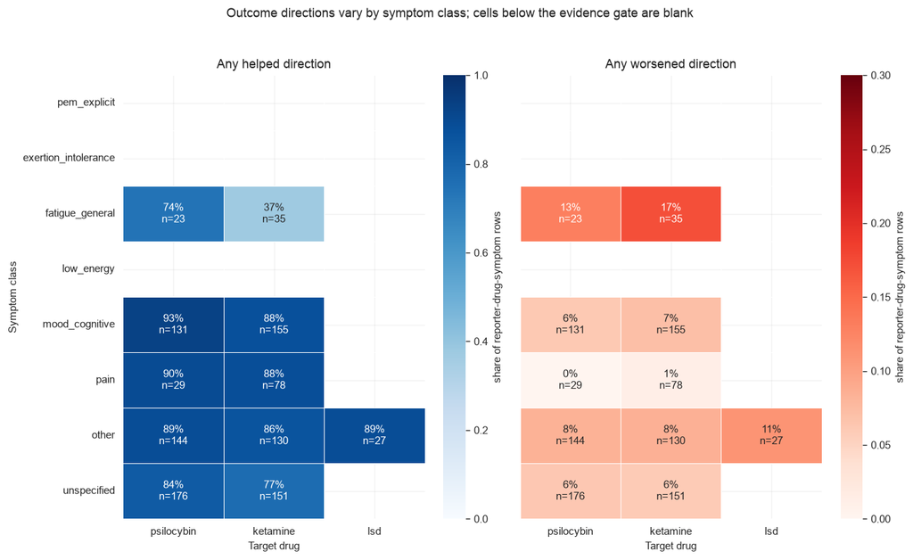

Within drug: symptom class vs the same drug's other symptom classes (drug, indication and access pattern held fixed).

| drug | symptom class | direction | focal rows | focal patients | rate (focal) | rate (reference) | reference rows | difference (pp) | diff low | diff high | Cohen h | interval | note |
| --- | --- | --- | --- | --- | --- | --- | --- | --- | --- | --- | --- | --- | --- |
| ketamine | fatigue_general | helped | 35 | 35 | 37.1% | 83.5% | 541 | -46.4 | -60.4 | -30.1 | -1.00 | interval below 0 |  |
| psilocybin | fatigue_general | helped | 23 | 23 | 73.9% | 87.2% | 507 | -13.3 | -33.3 | +4.2 | -0.34 | interval spans 0 |  |
| psilocybin | pain | worsened | 29 | 29 | 0.0% | 7.6% | 501 | -7.6 | -10.4 | -5.1 | -0.56 | interval below 0 | boundary rate — interval unreliable |
| ketamine | pain | worsened | 78 | 78 | 1.3% | 7.6% | 498 | -6.3 | -9.4 | -3.3 | -0.33 | interval below 0 |  |
| ketamine | unspecified | helped | 151 | 151 | 76.8% | 82.1% | 425 | -5.3 | -12.8 | +2.3 | -0.13 | interval spans 0 |  |
| psilocybin | unspecified | helped | 176 | 176 | 83.5% | 88.1% | 354 | -4.6 | -11.1 | +1.4 | -0.13 | interval spans 0 |  |
| psilocybin | mood_cognitive | worsened | 131 | 131 | 6.1% | 7.5% | 399 | -1.4 | -6.3 | +3.5 | -0.06 | interval spans 0 |  |
| psilocybin | unspecified | worsened | 176 | 176 | 6.2% | 7.6% | 354 | -1.4 | -5.4 | +2.6 | -0.05 | interval spans 0 |  |
| ketamine | unspecified | worsened | 151 | 151 | 6.0% | 7.1% | 425 | -1.1 | -5.7 | +3.7 | -0.04 | interval spans 0 |  |
| ketamine | mood_cognitive | worsened | 155 | 155 | 7.1% | 6.7% | 421 | +0.4 | -3.4 | +4.7 | +0.02 | interval spans 0 |  |
| psilocybin | other | worsened | 144 | 144 | 8.3% | 6.7% | 386 | +1.6 | -2.7 | +5.8 | +0.06 | interval spans 0 |  |
| ketamine | other | worsened | 130 | 130 | 8.5% | 6.3% | 446 | +2.2 | -2.3 | +6.8 | +0.08 | interval spans 0 |  |
| psilocybin | other | helped | 144 | 144 | 88.9% | 85.8% | 386 | +3.1 | -2.5 | +8.8 | +0.09 | interval spans 0 |  |
| psilocybin | pain | helped | 29 | 29 | 89.7% | 86.4% | 501 | +3.2 | -9.6 | +13.6 | +0.10 | interval spans 0 |  |
| lsd | other | worsened | 27 | 27 | 11.1% | 5.7% | 53 | +5.5 | -3.8 | +17.9 | +0.20 | interval spans 0 |  |
| lsd | other | helped | 27 | 27 | 88.9% | 83.0% | 53 | +5.9 | -11.7 | +21.8 | +0.17 | interval spans 0 |  |
| psilocybin | fatigue_general | worsened | 23 | 23 | 13.0% | 6.9% | 507 | +6.1 | -7.1 | +22.8 | +0.21 | interval spans 0 |  |
| ketamine | other | helped | 130 | 130 | 86.2% | 79.1% | 446 | +7.0 | +0.5 | +13.3 | +0.19 | interval above 0 |  |
| psilocybin | mood_cognitive | helped | 131 | 131 | 93.1% | 84.5% | 399 | +8.7 | +3.0 | +14.3 | +0.28 | interval above 0 |  |
| ketamine | pain | helped | 78 | 78 | 88.5% | 79.5% | 498 | +8.9 | +1.2 | +16.7 | +0.25 | interval above 0 |  |
| ketamine | mood_cognitive | helped | 155 | 155 | 87.7% | 78.1% | 421 | +9.6 | +3.4 | +15.6 | +0.26 | interval above 0 |  |
| ketamine | fatigue_general | worsened | 35 | 35 | 17.1% | 6.1% | 541 | +11.0 | -0.4 | +24.3 | +0.35 | interval spans 0 |  |

Within symptom class: drug vs the other drugs in the same class (symptom class held fixed).

| drug | symptom class | direction | focal rows | focal patients | rate (focal) | rate (reference) | reference rows | difference (pp) | diff low | diff high | Cohen h | interval | note |
| --- | --- | --- | --- | --- | --- | --- | --- | --- | --- | --- | --- | --- | --- |
| ketamine | fatigue_general | helped | 35 | 35 | 37.1% | 71.9% | 32 | -34.7 | -57.6 | -11.5 | -0.71 | interval below 0 |  |
| ketamine | unspecified | helped | 151 | 151 | 76.8% | 83.0% | 194 | -6.2 | -14.1 | +1.5 | -0.15 | interval spans 0 |  |
| ketamine | mood_cognitive | helped | 155 | 155 | 87.7% | 93.8% | 146 | -6.1 | -12.2 | +0.3 | -0.21 | interval spans 0 |  |
| ketamine | other | helped | 130 | 130 | 86.2% | 88.9% | 171 | -2.7 | -10.0 | +4.7 | -0.08 | interval spans 0 |  |
| psilocybin | pain | worsened | 29 | 29 | 0.0% | 2.4% | 82 | -2.4 | -6.2 | +0.0 | -0.31 | interval spans 0 | boundary rate — interval unreliable |
| ketamine | pain | worsened | 78 | 78 | 1.3% | 3.0% | 33 | -1.7 | -9.1 | +3.7 | -0.12 | interval spans 0 |  |
| ketamine | unspecified | worsened | 151 | 151 | 6.0% | 6.7% | 194 | -0.7 | -6.2 | +4.8 | -0.03 | interval spans 0 |  |
| psilocybin | fatigue_general | worsened | 23 | 23 | 13.0% | 13.6% | 44 | -0.6 | -16.9 | +16.9 | -0.02 | interval spans 0 |  |
| psilocybin | other | worsened | 144 | 144 | 8.3% | 8.9% | 157 | -0.6 | -6.8 | +6.2 | -0.02 | interval spans 0 |  |
| psilocybin | mood_cognitive | worsened | 131 | 131 | 6.1% | 6.5% | 170 | -0.4 | -6.0 | +5.2 | -0.01 | interval spans 0 |  |
| ketamine | other | worsened | 130 | 130 | 8.5% | 8.8% | 171 | -0.3 | -6.8 | +5.9 | -0.01 | interval spans 0 |  |
| psilocybin | unspecified | worsened | 176 | 176 | 6.2% | 6.5% | 169 | -0.3 | -5.5 | +4.7 | -0.01 | interval spans 0 |  |
| ketamine | pain | helped | 78 | 78 | 88.5% | 87.9% | 33 | +0.6 | -10.5 | +13.7 | +0.02 | interval spans 0 |  |
| lsd | other | helped | 27 | 27 | 88.9% | 87.6% | 274 | +1.3 | -12.2 | +12.8 | +0.04 | interval spans 0 |  |
| ketamine | mood_cognitive | worsened | 155 | 155 | 7.1% | 5.5% | 146 | +1.6 | -3.6 | +6.9 | +0.07 | interval spans 0 |  |
| psilocybin | pain | helped | 29 | 29 | 89.7% | 87.8% | 82 | +1.9 | -11.7 | +12.5 | +0.06 | interval spans 0 |  |
| psilocybin | other | helped | 144 | 144 | 88.9% | 86.6% | 157 | +2.3 | -5.1 | +9.2 | +0.07 | interval spans 0 |  |
| lsd | other | worsened | 27 | 27 | 11.1% | 8.4% | 274 | +2.7 | -8.3 | +16.5 | +0.09 | interval spans 0 |  |
| psilocybin | mood_cognitive | helped | 131 | 131 | 93.1% | 88.8% | 170 | +4.3 | -1.9 | +10.8 | +0.15 | interval spans 0 |  |
| psilocybin | unspecified | helped | 176 | 176 | 83.5% | 76.9% | 169 | +6.6 | -1.5 | +15.0 | +0.17 | interval spans 0 |  |
| ketamine | fatigue_general | worsened | 35 | 35 | 17.1% | 9.4% | 32 | +7.8 | -9.0 | +23.7 | +0.23 | interval spans 0 |  |
| psilocybin | fatigue_general | helped | 23 | 23 | 73.9% | 43.2% | 44 | +30.7 | +7.1 | +54.3 | +0.64 | interval above 0 |  |

**Plain-language verdict.** Among drug-symptom cells that clear the evidence gate, helped-reporting is highest for **psilocybin / mood_cognitive** at 93.1% (88.5%–96.9%, n=131) and lowest for **ketamine / fatigue_general** at 37.1% (22.9%–54.3%, n=35). The largest one-factor deviation is **ketamine / fatigue_general**: holding the drug fixed, helped-reporting in that symptom class runs **46.4 percentage points below** the same drug's other symptom classes (-60.4 to -30.1 pp, Cohen h=-1.00). Holding the symptom class fixed instead and moving the drug points the same way: ketamine runs 34.7 pp below the other drugs inside fatigue_general (-57.6 to -11.5 pp, 32 reference rows). Two contrasts that move different factors agreeing in sign is worth more than either alone. Note the sign: this is a deficit in reported benefit, not a benefit.

**And it is not a PEM result.** Every explicit-PEM cell falls below the evidence gate — the largest holds 9 rows from 9 reporter accounts — so no post-exertional-malaise estimate is reported for any drug. The deficit above is in *nonspecific fatigue*. The earlier composite class merged the two and reported the result as PEM.

13 of 24 cells fall below the gate and are excluded from these headlines, including every LSD cell outside `other`, whose apparent extremes on a handful of rows are artefacts of cell size. These are reporting shares, not probabilities that a drug will work or cause harm for a patient, and no hypothesis test is implied by any interval above.

GEE logistic model of helped-reporting, 1,052 rows from 661 reporter accounts; reference cell = psilocybin / mood_cognitive. Coefficients are log-odds, not probabilities, and no p-value is read.

| term | log-odds | 95% low | 95% high |
| --- | --- | --- | --- |
| Intercept | +2.47 | +1.88 | +3.07 |
| ketamine | -0.58 | -1.32 | +0.16 |
| fatigue_general | -1.50 | -2.53 | -0.46 |
| other | -0.43 | -1.09 | +0.23 |
| pain | -0.44 | -1.59 | +0.71 |
| unspecified | -0.74 | -1.43 | -0.05 |
| ketamine x fatigue_general | -1.07 | -2.38 | +0.24 |
| ketamine x other | +0.27 | -0.60 | +1.14 |
| ketamine x pain | +0.40 | -0.89 | +1.69 |
| ketamine x unspecified | +0.03 | -0.84 | +0.90 |

**Interaction.** The general-fatigue main effect is -1.50 log-odds (-2.53 to -0.46): across these drugs, general fatigue attracts less helped-reporting than mood/cognitive. The ketamine-by-general-fatigue interaction adds -1.07 (-2.38 to +0.24) on top of that — pointing the same way as the within-symptom contrast, but with an interval that includes zero. The model therefore supports 'general fatigue attracts less reported benefit' more strongly than it supports 'ketamine specifically'.

Within-drug helped-reporting contrast, exclusive display label vs multilabel membership.

| drug | symptom class | difference (pp) (exclusive) | diff low (exclusive) | diff high (exclusive) | focal rows (exclusive) | difference (pp) (multilabel) | diff low (multilabel) | diff high (multilabel) | focal rows (multilabel) |
| --- | --- | --- | --- | --- | --- | --- | --- | --- | --- |
| ketamine | fatigue_general | -46.4 | -60.4 | -30.1 | 35 | -38.1 | -52.2 | -23.5 | 44 |
| psilocybin | fatigue_general | -13.3 | -33.3 | +4.2 | 23 | -8.1 | -23.0 | +6.2 | 29 |
| ketamine | unspecified | -5.3 | -12.8 | +2.3 | 151 | -5.3 | -13.1 | +2.6 | 151 |
| psilocybin | unspecified | -4.6 | -11.1 | +1.4 | 176 | -5.1 | -11.2 | +1.0 | 176 |
| psilocybin | other | +3.1 | -2.5 | +8.8 | 144 | +2.6 | -3.2 | +8.0 | 144 |
| psilocybin | pain | +3.2 | -9.6 | +13.6 | 29 | +2.9 | -10.5 | +13.2 | 29 |
| lsd | other | +5.9 | -11.7 | +21.8 | 27 | +5.3 | -11.6 | +20.7 | 27 |
| ketamine | other | +7.0 | +0.5 | +13.3 | 130 | +6.8 | +0.3 | +13.4 | 130 |
| psilocybin | mood_cognitive | +8.7 | +3.0 | +14.3 | 131 | +8.3 | +2.8 | +13.5 | 133 |
| ketamine | pain | +8.9 | +1.2 | +16.7 | 78 | +8.8 | +1.2 | +15.7 | 78 |
| ketamine | mood_cognitive | +9.6 | +3.4 | +15.6 | 155 | +9.9 | +3.9 | +16.0 | 159 |
| ketamine | low_energy | below gate | below gate | below gate | below gate | -6.0 | -24.8 | +11.1 | 24 |
| psilocybin | low_energy | below gate | below gate | below gate | below gate | -6.2 | -25.8 | +9.9 | 21 |

**Sensitivity.** Multilabel assignment moves rows into the classes the precedence rule had taken them out of, which enlarges the fatigue and low-energy cells and shrinks nothing. The leading deficit is unchanged in sign and cell: ketamine / fatigue_general at -38.1 pp (-52.2 to -23.5, 44 rows), against -46.4 pp under the exclusive label. The attenuation is what dilution by less-affected records looks like; the direction does not depend on the labelling rule.

## 2. Within-person heterogeneity

Flattening all effects into one positive label would hide clinically relevant combinations. Here a reporter-drug pair is **helped only**, **no-effect only**, **worsened only**, or **mixed/conflicting** when it contains more than one direction or a mixed direction. The profile is descriptive and mutually exclusive; the underlying symptom directions can still span more than one symptom class.

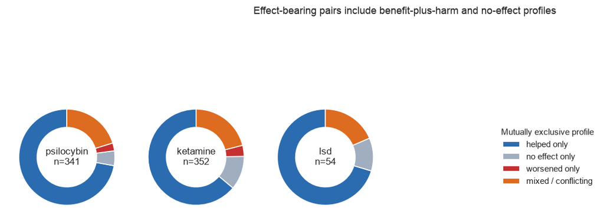

| profile drug | helped only | no effect only | worsened only | mixed / conflicting | effect-bearing pairs | benefit + worsening pairs | mean symptom classes |
| --- | --- | --- | --- | --- | --- | --- | --- |
| psilocybin | 246 | 17 | 9 | 69 | 341 | 18 | 1.55 |
| ketamine | 225 | 40 | 13 | 74 | 352 | 13 | 1.64 |
| lsd | 38 | 6 | 0 | 10 | 54 | 4 | 1.48 |

| drug | pairs | mixed / conflicting | 95% clustered CI | difference vs other drugs (pp) | diff low | diff high | interval | evidence |
| --- | --- | --- | --- | --- | --- | --- | --- | --- |
| psilocybin | 341 | 20.2% | 16.1%–24.6% | -0.5 | -6.4 | +5.5 | interval spans 0 | ok |
| ketamine | 352 | 21.0% | 17.0%–25.3% | +1.0 | -4.6 | +6.6 | interval spans 0 | ok |
| lsd | 54 | 18.5% | 9.3%–29.6% | -2.1 | -12.0 | +9.5 | interval spans 0 | ok |

**Comparison.** The mixed/conflicting share is psilocybin 20.2% (n=341), ketamine 21.0% (n=352), lsd 18.5% (n=54). Every cross-drug difference interval spans zero, so this comparison does not resolve a difference in profile distributions at this sample size — which is not the same as showing there is none; LSD has the smallest denominator and is the least stable. **Plain language:** 35 of 747 effect-bearing pairs contain both at least one helped and one worsened direction. Those benefit-plus-harm reports are a substantive outcome, not noise to be collapsed into 'positive'.

## 3. Adverse-event profile and co-occurrence

An adverse-event row is an extracted reported event. The pair-level outcomes below count any event, at least one severe event, an event marked ongoing at report, and more than one event. Missing severity remains its own category. These measures describe reporting patterns and cannot estimate incidence, attributable risk, or whether the drug caused the event.

One relationship is deliberately **not** presented as a finding. An adverse-event record and a `worsened` effect direction are frequently extracted from the same passage, and sometimes from the same claim, so "pairs reporting adverse category X are more likely to report worsening" is close to a restatement of the input rather than a discovery about the drug. An earlier draft of this notebook ranked nine such pairings as its leading results; §7 now excludes that scan and explains why. The co-occurrence table below is retained only as a description of how benefit and harm reports overlap within a pair.

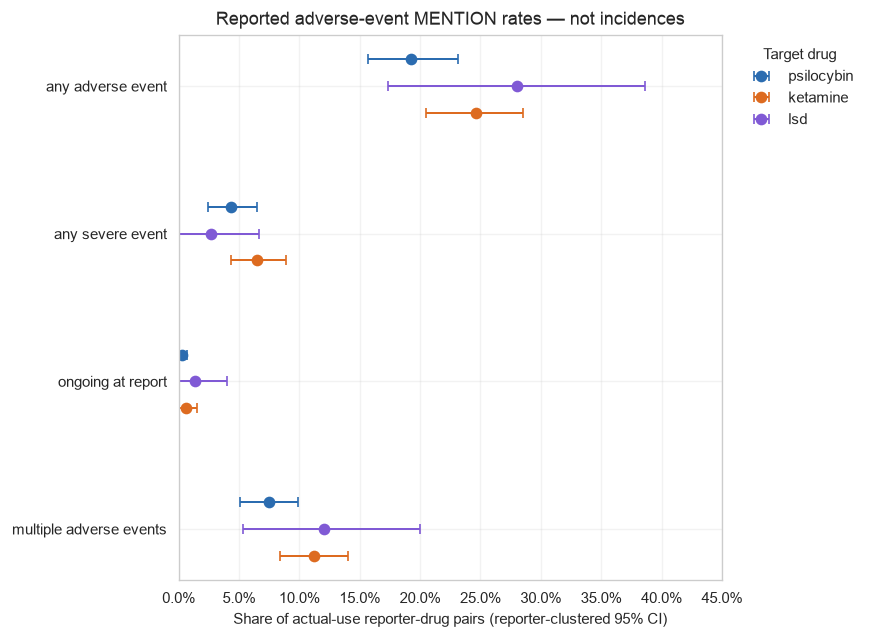

| drug | metric | k | n | rate | clustered 95% CI |
| --- | --- | --- | --- | --- | --- |
| psilocybin | any adverse event | 80 | 415 | 19.3% | 15.7%–23.1% |
| psilocybin | any severe event | 18 | 415 | 4.3% | 2.4%–6.5% |
| psilocybin | ongoing at report | 1 | 415 | 0.2% | 0.0%–0.7% |
| psilocybin | multiple adverse events | 31 | 415 | 7.5% | 5.1%–9.9% |
| ketamine | any adverse event | 114 | 463 | 24.6% | 20.5%–28.5% |
| ketamine | any severe event | 30 | 463 | 6.5% | 4.3%–8.9% |
| ketamine | ongoing at report | 3 | 463 | 0.6% | 0.0%–1.5% |
| ketamine | multiple adverse events | 52 | 463 | 11.2% | 8.4%–14.0% |
| lsd | any adverse event | 21 | 75 | 28.0% | 17.3%–38.7% |
| lsd | any severe event | 2 | 75 | 2.7% | 0.0%–6.7% |
| lsd | ongoing at report | 1 | 75 | 1.3% | 0.0%–4.0% |
| lsd | multiple adverse events | 9 | 75 | 12.0% | 5.3%–20.0% |

| metric | drug | rate (focal) | rate (other drugs) | focal pairs | difference (pp) | diff low | diff high | Cohen h | interval | evidence |
| --- | --- | --- | --- | --- | --- | --- | --- | --- | --- | --- |
| any adverse event | psilocybin | 19.3% | 25.1% | 415 | -5.8 | -11.0 | -0.7 | -0.14 | interval below 0 | ok |
| any adverse event | ketamine | 24.6% | 20.6% | 463 | +4.0 | -1.0 | +9.4 | +0.10 | interval spans 0 | ok |
| any adverse event | lsd | 28.0% | 22.1% | 75 | +5.9 | -4.1 | +16.7 | +0.14 | interval spans 0 | ok |
| any severe event | psilocybin | 4.3% | 5.9% | 415 | -1.6 | -4.4 | +1.2 | -0.07 | interval spans 0 | ok |
| any severe event | ketamine | 6.5% | 4.1% | 463 | +2.4 | -0.3 | +5.1 | +0.11 | interval spans 0 | ok |
| any severe event | lsd | 2.7% | 5.5% | 75 | -2.8 | -6.3 | +1.4 | -0.14 | interval spans 0 | ok |
| ongoing at report | psilocybin | 0.2% | 0.7% | 415 | -0.5 | -1.4 | +0.3 | -0.07 | interval spans 0 | ok |
| ongoing at report | ketamine | 0.6% | 0.4% | 463 | +0.2 | -0.6 | +1.1 | +0.03 | interval spans 0 | ok |
| ongoing at report | lsd | 1.3% | 0.5% | 75 | +0.9 | -0.8 | +4.1 | +0.10 | interval spans 0 | ok |
| multiple adverse events | psilocybin | 7.5% | 11.3% | 415 | -3.9 | -7.4 | -0.2 | -0.13 | interval below 0 | ok |
| multiple adverse events | ketamine | 11.2% | 8.2% | 463 | +3.1 | -0.3 | +6.8 | +0.10 | interval spans 0 | ok |
| multiple adverse events | lsd | 12.0% | 9.5% | 75 | +2.5 | -4.7 | +10.4 | +0.08 | interval spans 0 | ok |

**Comparison.** 2 of 12 gated drug-vs-rest adverse-event differences have an interval clear of zero: psilocybin / any adverse event -5.8 pp; psilocybin / multiple adverse events -3.9 pp. Any separation here is first of all a difference in reporting context — ketamine exposure in this cohort is largely IV/IM by stated route. This run records no administration-setting field, so nothing here establishes a supervision or clinic context — only a route difference. These are mention rates, never incidences.

| category | ketamine / mild | ketamine / missing severity | ketamine / moderate | ketamine / severe | lsd / mild | lsd / missing severity | lsd / moderate | lsd / severe | psilocybin / mild | psilocybin / missing severity | psilocybin / moderate | psilocybin / severe |
| --- | --- | --- | --- | --- | --- | --- | --- | --- | --- | --- | --- | --- |
| other | 17 | 27 | 44 | 35 | 3 | 5 | 10 | 2 | 25 | 10 | 38 | 11 |
| fatigue_pem_flare | 17 | 6 | 27 | 7 | 1 | 2 | 5 | 1 | 7 | 2 | 20 | 15 |
| anxiety_panic | 3 | 0 | 11 | 4 | 0 | 0 | 1 | 0 | 6 | 0 | 7 | 7 |
| nausea_gi | 3 | 3 | 6 | 3 | 1 | 0 | 0 | 0 | 6 | 0 | 10 | 1 |
| dissociation | 7 | 1 | 5 | 3 | 0 | 0 | 0 | 0 | 0 | 0 | 1 | 0 |
| cardiac | 3 | 0 | 3 | 0 | 0 | 0 | 2 | 0 | 0 | 1 | 5 | 1 |
| headache | 1 | 1 | 0 | 2 | 1 | 0 | 1 | 0 | 5 | 0 | 3 | 1 |
| insomnia | 2 | 1 | 2 | 2 | 2 | 0 | 0 | 0 | 1 | 0 | 0 | 0 |
| derealization | 1 | 0 | 1 | 2 | 0 | 0 | 0 | 0 | 0 | 0 | 1 | 1 |

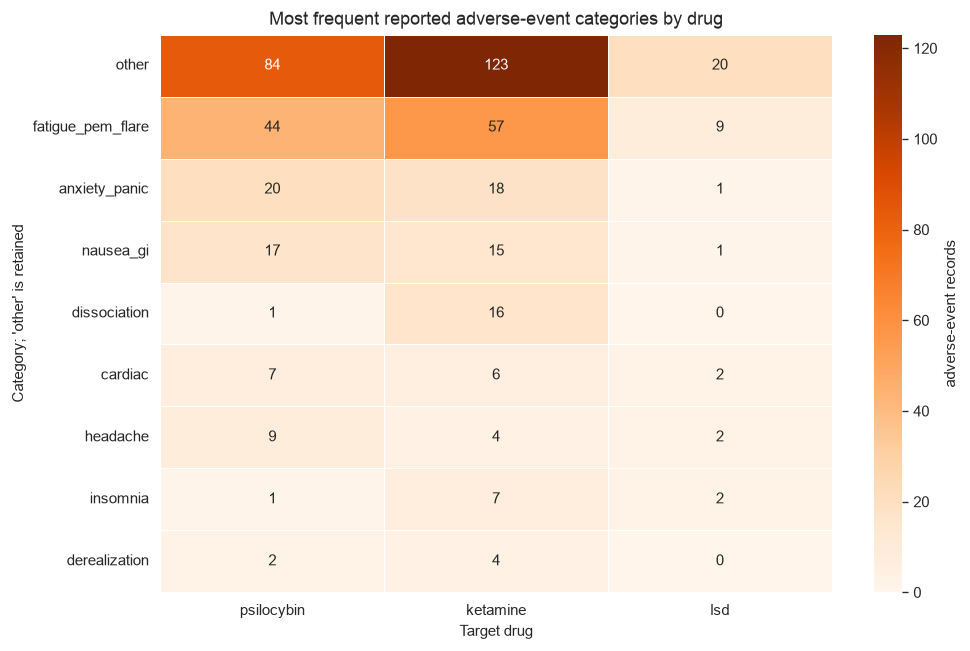

| drug | effect profile signal | AE-bearing pairs | profile pairs | AE share within profile | evidence |
| --- | --- | --- | --- | --- | --- |
| psilocybin | helped | 60 | 304 | 19.7% | ok |
| psilocybin | worsened | 26 | 32 | 81.2% | ok |
| psilocybin | mixed_conflicting | 35 | 69 | 50.7% | ok |
| ketamine | helped | 70 | 294 | 23.8% | ok |
| ketamine | worsened | 27 | 30 | 90.0% | ok |
| ketamine | mixed_conflicting | 35 | 74 | 47.3% | ok |
| lsd | helped | 14 | 46 | 30.4% | ok |
| lsd | worsened | 1 | 4 | 25.0% | insufficient |
| lsd | mixed_conflicting | 4 | 10 | 40.0% | insufficient |

**Interpretation.** This table describes how often a pair carrying a helped, worsened, or mixed/conflicting effect signal also carries an adverse-event record. It establishes no temporal order and no causation, and it is *not* evidence that harm follows from a direction label: a worsened direction and an adverse event are often extracted from the same sentence, so their overlap is partly an artefact of how the text was segmented. The reason to keep it visible is the opposite of a finding — a reported adverse event coexists with reported benefit often enough that collapsing a pair to 'positive' would hide it.

## 4. Duration and persistence

Duration is a stated field on only a small fraction of extracted effects. The categories are reported as acute/short-lived, intermediate, long-lasting, or ongoing at report. The **91% unstated-duration limitation applies to every duration interpretation below**: the chart describes the distribution among stated durations and does not show how long unreported effects lasted.

| drug | direction | symptom_class | duration class | effect records |
| --- | --- | --- | --- | --- |
| psilocybin | helped | mood_cognitive | intermediate | 19 |
| ketamine | helped | unspecified | intermediate | 18 |
| psilocybin | helped | other | intermediate | 17 |
| psilocybin | helped | unspecified | acute / short-lived | 14 |
| ketamine | helped | unspecified | acute / short-lived | 12 |
| psilocybin | helped | unspecified | intermediate | 11 |
| psilocybin | helped | mood_cognitive | long-lasting | 10 |
| psilocybin | helped | mood_cognitive | ongoing at report | 9 |
| psilocybin | helped | mood_cognitive | acute / short-lived | 9 |
| ketamine | helped | unspecified | long-lasting | 9 |
| ketamine | helped | mood_cognitive | intermediate | 8 |
| ketamine | helped | other | ongoing at report | 7 |
| psilocybin | helped | other | acute / short-lived | 7 |
| psilocybin | helped | other | ongoing at report | 7 |
| psilocybin | helped | unspecified | long-lasting | 6 |
| psilocybin | helped | other | long-lasting | 5 |
| ketamine | helped | mood_cognitive | ongoing at report | 5 |
| ketamine | helped | mood_cognitive | long-lasting | 5 |
| ketamine | helped | pain | intermediate | 4 |
| ketamine | helped | other | intermediate | 4 |
| lsd | helped | unspecified | acute / short-lived | 4 |
| lsd | helped | other | acute / short-lived | 4 |
| ketamine | helped | unspecified | ongoing at report | 3 |
| psilocybin | helped | unspecified | ongoing at report | 3 |
| psilocybin | mixed | unspecified | acute / short-lived | 3 |
| lsd | helped | fatigue_general | intermediate | 3 |
| ketamine | helped | other | long-lasting | 3 |
| psilocybin | helped | pain | acute / short-lived | 3 |
| psilocybin | helped | pain | intermediate | 3 |
| ketamine | helped | pain | acute / short-lived | 3 |

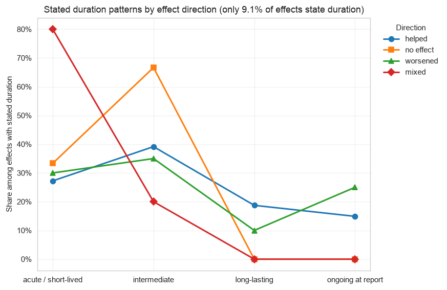

| direction | duration class | records | records with duration | share | ci low | ci high | evidence |
| --- | --- | --- | --- | --- | --- | --- | --- |
| helped | acute / short-lived | 64 | 235 | 27.2% | 20.5% | 35.0% | ok |
| helped | intermediate | 92 | 235 | 39.1% | 30.9% | 48.5% | ok |
| helped | long-lasting | 44 | 235 | 18.7% | 13.3% | 24.6% | ok |
| helped | ongoing at report | 35 | 235 | 14.9% | 7.8% | 22.0% | ok |
| no_effect | acute / short-lived | 1 | 3 | 33.3% | 0.0% | 100.0% | insufficient |
| no_effect | intermediate | 2 | 3 | 66.7% | 0.0% | 100.0% | insufficient |
| no_effect | long-lasting | 0 | 3 | 0.0% | 0.0% | 0.0% | insufficient |
| no_effect | ongoing at report | 0 | 3 | 0.0% | 0.0% | 0.0% | insufficient |
| worsened | acute / short-lived | 6 | 20 | 30.0% | 9.7% | 58.8% | ok |
| worsened | intermediate | 7 | 20 | 35.0% | 15.8% | 61.1% | ok |
| worsened | long-lasting | 2 | 20 | 10.0% | 0.0% | 21.7% | ok |
| worsened | ongoing at report | 5 | 20 | 25.0% | 0.0% | 45.2% | ok |
| mixed | acute / short-lived | 4 | 5 | 80.0% | 40.0% | 100.0% | insufficient |
| mixed | intermediate | 1 | 5 | 20.0% | 0.0% | 60.0% | insufficient |
| mixed | long-lasting | 0 | 5 | 0.0% | 0.0% | 0.0% | insufficient |
| mixed | ongoing at report | 0 | 5 | 0.0% | 0.0% | 0.0% | insufficient |

**Comparison.** Among the 263 effect records that state a duration, the class mix is tabulated above per direction with reporter-clustered intervals. No test of association is reported: the rows are clustered inside reporter accounts and the interesting quantity here is coverage, not a contingency statistic. The no_effect, mixed direction(s) fall below the evidence gate. **Plain language:** this describes the 9.1% of effect records with a duration field, not persistence. The remaining 90.9% are unstated and cannot be classified as short-lived, long-lasting, or ongoing — in particular, an effect with no stated duration is not a short one.

## 5. Dose and use-context coverage

Dose amounts are analyzed only inside compatible canonical units. Grams of psilocybin and milligrams of ketamine are never pooled with each other or with count-based records.

**Route is reported for ketamine only, and route is not a setting.** Ketamine is the one arm where the stated route varies at all: its records split between IV/IM and intranasal, sublingual, and oral. Psilocybin is oral wherever a route is stated, so the field adds nothing, and **no LSD dose record states a route at all**. Coverage for all three is still tabulated — the asymmetry in what each community writes down is itself informative.

**This run measures no administration setting.** There is no structured supervision or context field in the loaded data, and route does not stand in for one: intranasal esketamine is routinely clinic-administered, and an injection label documents no supervision either. So no group below is called clinic, supervised, self-administered, or take-home, and no difference elsewhere in this notebook is explained by setting.

**LSD numeric dosing is reported as insufficient data.** The next cells quantify how thin it is rather than binning it into a result.

| drug field | ketamine | lsd | psilocybin |
| --- | --- | --- | --- |
| dose records | 557 | 74 | 707 |
| amount + unit | 50 | 19 | 195 |
| route stated | 361 | 0 | 109 |
| intent stated | 85 | 43 | 394 |
| formulation stated | 104 | 5 | 141 |
| schedule stated | 170 | 14 | 157 |
| context stated | 258 | 5 | 59 |

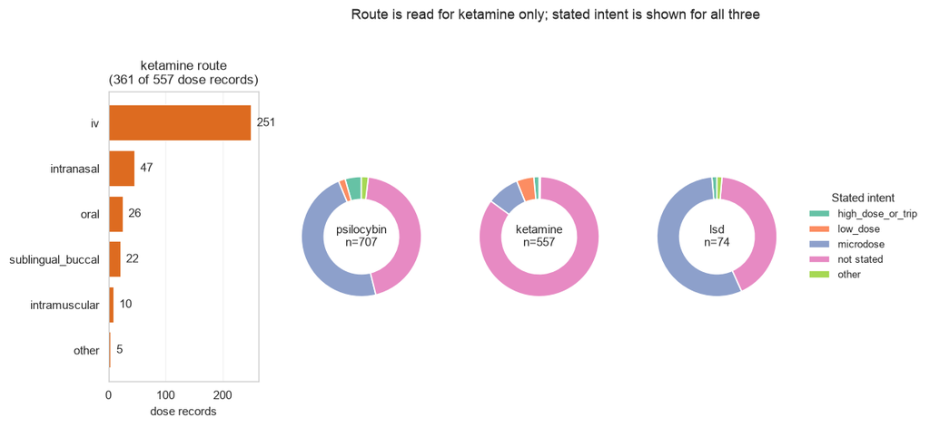

| route group | route_canon | records | reporters | % of stated-route records |
| --- | --- | --- | --- | --- |
| IV/IM stated route | iv | 251 | 117 | 69.5% |
| other stated routes | intranasal | 47 | 27 | 13.0% |
|  | oral | 26 | 15 | 7.2% |
|  | sublingual_buccal | 22 | 9 | 6.1% |
| IV/IM stated route | intramuscular | 10 | 9 | 2.8% |
| other stated routes | other | 5 | 3 | 1.4% |

**Interpretation.** Of 361 ketamine dose records that state a route (65% of 557), 72% state an IV or IM route and 28% state an intranasal, sublingual/buccal, or oral route. **Route is not a proxy for setting.** Intranasal esketamine is commonly given under supervision and an injection label does not document supervision either, so neither group can be called clinic-administered or self-administered. A treatment-context field exists on only 46% of ketamine dose records and is not loaded as structured text, so administration setting is **unmeasured in this run** and is not used to explain any difference in this notebook. Route is not interpreted for psilocybin (oral wherever stated) or LSD (never stated), and none of these distributions should be read as representative prescribing or use patterns.

### Compatible-unit dose bins, where there are enough of them

Numeric amounts are lower bounds when the extractor stored a range. Bins are defined only inside a drug/unit-compatible subset and are never pooled across units. They are retained as reporting associations, described with clustered intervals and effect sizes — no test, no dose-response language, no causal reading.

**Each dose is linked to outcomes from its own claim.** A claim is one extracted exposure event and is the finest key the probe stores that a dose and an outcome are known to share. An earlier version joined doses to outcomes on reporter and drug alone, which copied a reporter's entire outcome summary onto every dose bin they had ever mentioned — so one reported benefit could count as evidence for 1 g and 5 g at once. Two exclusions are applied before any outcome is read, and both are counted in the audit below: a claim whose dose records straddle more than one bin is ambiguous and is dropped whole, and a claim carrying no effect record has no outcome to link.

Coverage then decides which subsets are eligible at all. The next cell reports each candidate subset against the evidence gate and states plainly where there is **insufficient data**, rather than drawing a panel over a handful of records.

| drug | unit | records | reporters | claims | candidate |
| --- | --- | --- | --- | --- | --- |
| ketamine | mg | 42 | 25 | 34 | yes |
| ketamine | mg/kg | 5 | 3 | 4 | no — not a binnable vocabulary |
| ketamine | count | 2 | 2 | 2 | no — not a binnable vocabulary |
| ketamine | other | 1 | 1 | 1 | no — not a binnable vocabulary |
| lsd | mcg | 11 | 9 | 11 | no — not a binnable vocabulary |
| lsd | count | 8 | 3 | 8 | no — not a binnable vocabulary |
| psilocybin | g | 155 | 94 | 132 | yes |
| psilocybin | mg | 35 | 22 | 32 | no — not a binnable vocabulary |
| psilocybin | oz | 4 | 1 | 4 | no — not a binnable vocabulary |
| psilocybin | count | 1 | 1 | 1 | no — not a binnable vocabulary |

| step | records | claims |
| --- | --- | --- |
| dose records with amount + canonical unit | 264 | 226 |
| in a binned drug/unit subset | 197 | 166 |
| excluded: claim straddles >1 dose bin | 26 | 12 |
| excluded: claim carries no effect record | 49 | 32 |
| retained for dose/outcome analysis | 122 | 122 |

**LSD dosing: insufficient data.** Of 74 LSD dose records, 19 carry an amount with a canonical unit, and only 11 of those are in micrograms (from 9 reporters); the rest are unitless tab or blotter counts whose strength is unknown. Splitting 11 records across dose bands would produce bands of three or four records each and error bars wider than the entire outcome scale. No LSD dose panel, bin comparison, or dose-related statement is reported anywhere in this notebook. Recovering LSD dosing would need either a much larger cohort or a documented per-tab strength assumption, and this notebook has neither.

| dose group | status |
| --- | --- |
| ketamine / mg | INSUFFICIENT DATA — not interpreted |
| psilocybin / g | described |

| dose group | dose bin | outcome | k | n | reporters | rate | clustered 95% CI | evidence |
| --- | --- | --- | --- | --- | --- | --- | --- | --- |
| ketamine / mg | ≤50 mg | helped | 10 | 10 | 9 | 100.0% | 100.0%–100.0% | thin |
| ketamine / mg | ≤50 mg | worsened | 0 | 10 | 9 | 0.0% | 0.0%–0.0% | thin |
| psilocybin / g | >3 g | helped | 22 | 26 | 20 | 84.6% | 63.0%–100.0% | ok |
| psilocybin / g | >3 g | worsened | 5 | 26 | 20 | 19.2% | 0.0%–41.9% | ok |
| psilocybin / g | 1–3 g | helped | 18 | 21 | 19 | 85.7% | 66.7%–100.0% | ok |
| psilocybin / g | 1–3 g | worsened | 2 | 21 | 19 | 9.5% | 0.0%–25.0% | ok |
| psilocybin / g | ≤1 g | helped | 47 | 53 | 38 | 88.7% | 77.9%–98.0% | ok |
| psilocybin / g | ≤1 g | worsened | 4 | 53 | 38 | 7.5% | 0.0%–17.3% | ok |
| ketamine / mg | >100 mg | helped | 8 | 8 | 7 | 100.0% | 100.0%–100.0% | thin |
| ketamine / mg | >100 mg | worsened | 0 | 8 | 7 | 0.0% | 0.0%–0.0% | thin |
| ketamine / mg | 51–100 mg | helped | 3 | 4 | 3 | 75.0% | 50.0%–100.0% | thin |
| ketamine / mg | 51–100 mg | worsened | 0 | 4 | 3 | 0.0% | 0.0%–0.0% | thin |

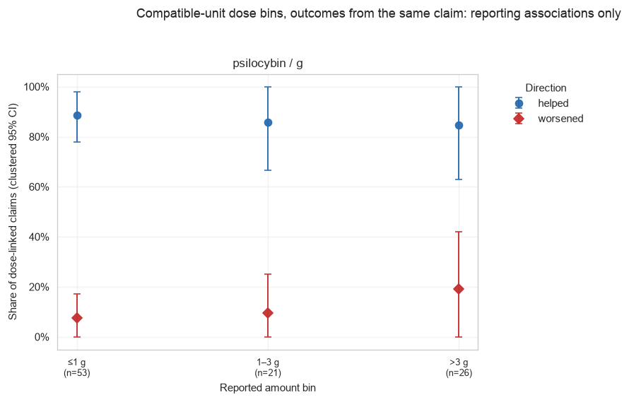

| dose group | outcome | comparison | n comparison | n reference | difference (pp) | diff low | diff high | Cohen h | interval | evidence |
| --- | --- | --- | --- | --- | --- | --- | --- | --- | --- | --- |
| psilocybin / g | worsened | >3 g vs ≤1 g | 26 | 53 | +11.7 | -10.3 | +36.7 | +0.35 | interval spans 0 | ok |
| psilocybin / g | helped | >3 g vs ≤1 g | 26 | 53 | -4.1 | -29.0 | +15.7 | -0.12 | interval spans 0 | ok |
| psilocybin / g | helped | 1–3 g vs ≤1 g | 21 | 53 | -3.0 | -27.3 | +16.9 | -0.09 | interval spans 0 | ok |
| psilocybin / g | worsened | 1–3 g vs ≤1 g | 21 | 53 | +2.0 | -12.3 | +19.1 | +0.07 | interval spans 0 | ok |

**Plain-language verdict.** These panels only show how reported outcomes differ across bins that share a drug *and* a unit, using only outcomes reported in the same claim as the dose. 0 of 4 bin comparisons sit below the evidence gate and are marked thin; LSD and ketamine are absent entirely for insufficient data once the linkage is claim-level. Amount ranges stored as lower bounds, extraction error, and confounding by indication and unmeasured setting make every row above unsuitable for dose selection. No comparison here supports the claim that a higher dose caused a different outcome, and no dose-response relationship is estimated — chronology is not recoverable from this dataset at all.

## 6. Robustness and extraction sensitivity

The main sensitivity checks use the same pair-level outcome definitions while changing which records are included: all extracted records, high-confidence effect records only, removal of the three most prolific reporter-drug pairs by included-claim count, and patients who report only one target drug. Clustered bootstrap intervals are used throughout. These checks test stability of reporting summaries; they do not repair unvalidated extraction.

| scenario | drug | outcome | k | n | patients | rate | clustered 95% CI | evidence |
| --- | --- | --- | --- | --- | --- | --- | --- | --- |
| all actual-use effects | psilocybin | helped | 304 | 341 | 341 | 89.1% | 85.6%-92.4% | ok |
| all actual-use effects | psilocybin | worsened | 32 | 341 | 341 | 9.4% | 6.7%-12.3% | ok |
| all actual-use effects | ketamine | helped | 294 | 352 | 352 | 83.5% | 79.5%-87.5% | ok |
| all actual-use effects | ketamine | worsened | 30 | 352 | 352 | 8.5% | 5.7%-11.6% | ok |
| all actual-use effects | lsd | helped | 46 | 54 | 54 | 85.2% | 75.9%-94.4% | ok |
| all actual-use effects | lsd | worsened | 4 | 54 | 54 | 7.4% | 1.9%-14.8% | ok |
| high-confidence effects | psilocybin | helped | 242 | 278 | 278 | 87.1% | 83.1%-90.7% | ok |
| high-confidence effects | psilocybin | worsened | 31 | 278 | 278 | 11.2% | 7.6%-14.8% | ok |
| high-confidence effects | ketamine | helped | 234 | 291 | 291 | 80.4% | 75.6%-84.9% | ok |
| high-confidence effects | ketamine | worsened | 30 | 291 | 291 | 10.3% | 6.9%-14.1% | ok |
| high-confidence effects | lsd | helped | 40 | 48 | 48 | 83.3% | 72.9%-93.8% | ok |
| high-confidence effects | lsd | worsened | 4 | 48 | 48 | 8.3% | 2.1%-16.7% | ok |
| remove 3 prolific pairs | psilocybin | helped | 303 | 340 | 340 | 89.1% | 85.6%-92.4% | ok |
| remove 3 prolific pairs | psilocybin | worsened | 32 | 340 | 340 | 9.4% | 6.5%-12.6% | ok |
| remove 3 prolific pairs | ketamine | helped | 292 | 350 | 350 | 83.4% | 79.7%-87.1% | ok |
| remove 3 prolific pairs | ketamine | worsened | 29 | 350 | 350 | 8.3% | 5.4%-11.1% | ok |
| remove 3 prolific pairs | lsd | helped | 46 | 54 | 54 | 85.2% | 74.1%-94.4% | ok |
| remove 3 prolific pairs | lsd | worsened | 4 | 54 | 54 | 7.4% | 1.9%-14.8% | ok |
| single-target-drug patients | psilocybin | helped | 266 | 296 | 296 | 89.9% | 86.5%-93.2% | ok |
| single-target-drug patients | psilocybin | worsened | 25 | 296 | 296 | 8.4% | 5.4%-11.8% | ok |
| single-target-drug patients | ketamine | helped | 268 | 316 | 316 | 84.8% | 80.7%-88.6% | ok |
| single-target-drug patients | ketamine | worsened | 26 | 316 | 316 | 8.2% | 5.7%-11.4% | ok |
| single-target-drug patients | lsd | helped | 27 | 30 | 30 | 90.0% | 80.0%-100.0% | ok |
| single-target-drug patients | lsd | worsened | 3 | 30 | 30 | 10.0% | 0.0%-20.0% | ok |

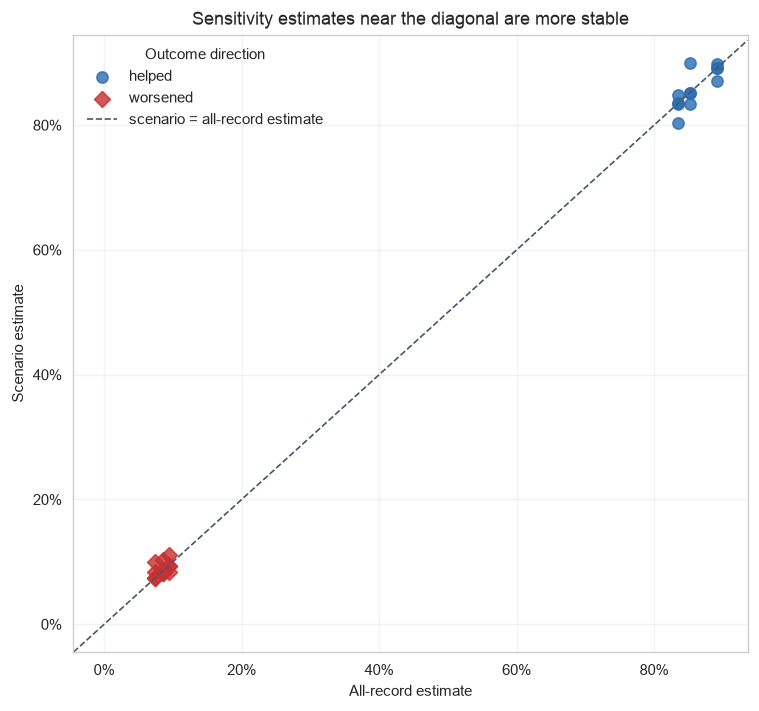

| scenario | drug | outcome | n | patients | rate | shift (pp) |
| --- | --- | --- | --- | --- | --- | --- |
| single-target-drug patients | lsd | helped | 30 | 30 | 90.0% | +4.8 |
| high-confidence effects | ketamine | helped | 291 | 291 | 80.4% | -3.1 |
| single-target-drug patients | lsd | worsened | 30 | 30 | 10.0% | +2.6 |
| high-confidence effects | psilocybin | helped | 278 | 278 | 87.1% | -2.1 |
| high-confidence effects | lsd | helped | 48 | 48 | 83.3% | -1.9 |
| high-confidence effects | ketamine | worsened | 291 | 291 | 10.3% | +1.8 |
| high-confidence effects | psilocybin | worsened | 278 | 278 | 11.2% | +1.8 |
| single-target-drug patients | ketamine | helped | 316 | 316 | 84.8% | +1.3 |
| single-target-drug patients | psilocybin | worsened | 296 | 296 | 8.4% | -0.9 |
| high-confidence effects | lsd | worsened | 48 | 48 | 8.3% | +0.9 |
| single-target-drug patients | psilocybin | helped | 296 | 296 | 89.9% | +0.7 |
| single-target-drug patients | ketamine | worsened | 316 | 316 | 8.2% | -0.3 |
| remove 3 prolific pairs | ketamine | worsened | 350 | 350 | 8.3% | -0.2 |
| remove 3 prolific pairs | ketamine | helped | 350 | 350 | 83.4% | -0.1 |
| remove 3 prolific pairs | psilocybin | helped | 340 | 340 | 89.1% | -0.0 |
| remove 3 prolific pairs | psilocybin | worsened | 340 | 340 | 9.4% | +0.0 |
| remove 3 prolific pairs | lsd | helped | 54 | 54 | 85.2% | +0.0 |
| remove 3 prolific pairs | lsd | worsened | 54 | 54 | 7.4% | +0.0 |
| all actual-use effects | psilocybin | worsened | 341 | 341 | 9.4% | +0.0 |
| all actual-use effects | lsd | worsened | 54 | 54 | 7.4% | +0.0 |
| all actual-use effects | lsd | helped | 54 | 54 | 85.2% | +0.0 |
| all actual-use effects | ketamine | worsened | 352 | 352 | 8.5% | +0.0 |
| all actual-use effects | ketamine | helped | 352 | 352 | 83.5% | +0.0 |
| all actual-use effects | psilocybin | helped | 341 | 341 | 89.1% | +0.0 |

**Robustness verdict.** Across scenario estimates that clear the evidence gate, the largest shift from the all-record estimate is +4.8 percentage points (lsd / helped, single-target-drug patients, n=30). Shifts of this size are a reminder that cluster composition and extraction confidence move these summaries; they are not a validation of them. Every scenario estimate shown clears the evidence gate, but LSD clears it only barely and its shifts are the least stable on the list.

## 7. Patterns worth investigating

This is a **magnitude-ranked screen**, not a test. It ranks the one-factor contrasts of §1 — each cell against the same drug's other symptom classes, and each cell against the other drugs inside the same symptom class — reported as differences in percentage points with reporter-clustered bootstrap intervals and Cohen's *h*. Cells below the evidence gate never enter the ranking. There is no p-value, no false-discovery-rate adjustment, and no threshold that promotes a row to a finding.

**The comparison changed.** An earlier version compared each drug-symptom cell against the whole rest of the corpus, which moved drug, symptom class, indication, route, access pattern and reporter composition all at once; a difference from that reference could not be read as a statement about the symptom class. Every row below holds one of those fixed. The two comparisons are ranked separately and are not pooled.

**One scan was removed.** An earlier version also screened drug × adverse-event-category against the `worsened` direction and reported nine "FDR survivors" as its leading results. Those comparisons are close to tautological: an adverse-event record and a worsened effect direction are routinely extracted from the same passage, so pairs that report an anxiety or fatigue event are nearly guaranteed to also carry a worsened direction. The leading such row rested on **two reporter accounts** and cleared its threshold anyway, which is a good illustration of why multiplicity adjustment does not rescue a screen whose inputs are not independent. That scan is gone; §3 retains the overlap only as a description.

The screen is also **direction-aware**. A cell can deviate by reporting *less* benefit, and the sign is printed in every row and every sentence.

| comparison | drug | symptom class | direction | direction of deviation | focal rows | focal patients | rate (focal) | rate (reference) | reference rows | difference (pp) | diff low | diff high | Cohen h | interval | note |
| --- | --- | --- | --- | --- | --- | --- | --- | --- | --- | --- | --- | --- | --- | --- | --- |
| within drug | ketamine | fatigue_general | helped | below reference | 35 | 35 | 37.1% | 83.5% | 541 | -46.4 | -60.4 | -30.1 | -1.00 | interval below 0 |  |
| within symptom | ketamine | fatigue_general | helped | below reference | 35 | 35 | 37.1% | 71.9% | 32 | -34.7 | -57.6 | -11.5 | -0.71 | interval below 0 |  |
| within symptom | psilocybin | fatigue_general | helped | above reference | 23 | 23 | 73.9% | 43.2% | 44 | +30.7 | +7.1 | +54.3 | +0.64 | interval above 0 |  |
| within drug | psilocybin | fatigue_general | helped | below reference | 23 | 23 | 73.9% | 87.2% | 507 | -13.3 | -33.3 | +4.2 | -0.34 | interval spans 0 |  |
| within drug | ketamine | fatigue_general | worsened | above reference | 35 | 35 | 17.1% | 6.1% | 541 | +11.0 | -0.4 | +24.3 | +0.35 | interval spans 0 |  |
| within drug | ketamine | mood_cognitive | helped | above reference | 155 | 155 | 87.7% | 78.1% | 421 | +9.6 | +3.4 | +15.6 | +0.26 | interval above 0 |  |
| within drug | ketamine | pain | helped | above reference | 78 | 78 | 88.5% | 79.5% | 498 | +8.9 | +1.2 | +16.7 | +0.25 | interval above 0 |  |
| within drug | psilocybin | mood_cognitive | helped | above reference | 131 | 131 | 93.1% | 84.5% | 399 | +8.7 | +3.0 | +14.3 | +0.28 | interval above 0 |  |
| within symptom | ketamine | fatigue_general | worsened | above reference | 35 | 35 | 17.1% | 9.4% | 32 | +7.8 | -9.0 | +23.7 | +0.23 | interval spans 0 |  |
| within drug | psilocybin | pain | worsened | below reference | 29 | 29 | 0.0% | 7.6% | 501 | -7.6 | -10.4 | -5.1 | -0.56 | interval below 0 | boundary rate — interval unreliable |
| within drug | ketamine | other | helped | above reference | 130 | 130 | 86.2% | 79.1% | 446 | +7.0 | +0.5 | +13.3 | +0.19 | interval above 0 |  |
| within symptom | psilocybin | unspecified | helped | above reference | 176 | 176 | 83.5% | 76.9% | 169 | +6.6 | -1.5 | +15.0 | +0.17 | interval spans 0 |  |
| within drug | ketamine | pain | worsened | below reference | 78 | 78 | 1.3% | 7.6% | 498 | -6.3 | -9.4 | -3.3 | -0.33 | interval below 0 |  |
| within symptom | ketamine | unspecified | helped | below reference | 151 | 151 | 76.8% | 83.0% | 194 | -6.2 | -14.1 | +1.5 | -0.15 | interval spans 0 |  |
| within drug | psilocybin | fatigue_general | worsened | above reference | 23 | 23 | 13.0% | 6.9% | 507 | +6.1 | -7.1 | +22.8 | +0.21 | interval spans 0 |  |
| within symptom | ketamine | mood_cognitive | helped | below reference | 155 | 155 | 87.7% | 93.8% | 146 | -6.1 | -12.2 | +0.3 | -0.21 | interval spans 0 |  |
| within drug | lsd | other | helped | above reference | 27 | 27 | 88.9% | 83.0% | 53 | +5.9 | -11.7 | +21.8 | +0.17 | interval spans 0 |  |
| within drug | lsd | other | worsened | above reference | 27 | 27 | 11.1% | 5.7% | 53 | +5.5 | -3.8 | +17.9 | +0.20 | interval spans 0 |  |
| within drug | ketamine | unspecified | helped | below reference | 151 | 151 | 76.8% | 82.1% | 425 | -5.3 | -12.8 | +2.3 | -0.13 | interval spans 0 |  |
| within drug | psilocybin | unspecified | helped | below reference | 176 | 176 | 83.5% | 88.1% | 354 | -4.6 | -11.1 | +1.4 | -0.13 | interval spans 0 |  |
| within symptom | psilocybin | mood_cognitive | helped | above reference | 131 | 131 | 93.1% | 88.8% | 170 | +4.3 | -1.9 | +10.8 | +0.15 | interval spans 0 |  |
| within drug | psilocybin | pain | helped | above reference | 29 | 29 | 89.7% | 86.4% | 501 | +3.2 | -9.6 | +13.6 | +0.10 | interval spans 0 |  |
| within drug | psilocybin | other | helped | above reference | 144 | 144 | 88.9% | 85.8% | 386 | +3.1 | -2.5 | +8.8 | +0.09 | interval spans 0 |  |
| within symptom | ketamine | other | helped | below reference | 130 | 130 | 86.2% | 88.9% | 171 | -2.7 | -10.0 | +4.7 | -0.08 | interval spans 0 |  |
| within symptom | lsd | other | worsened | above reference | 27 | 27 | 11.1% | 8.4% | 274 | +2.7 | -8.3 | +16.5 | +0.09 | interval spans 0 |  |
| within symptom | psilocybin | pain | worsened | below reference | 29 | 29 | 0.0% | 2.4% | 82 | -2.4 | -6.2 | +0.0 | -0.31 | interval spans 0 | boundary rate — interval unreliable |
| within symptom | psilocybin | other | helped | above reference | 144 | 144 | 88.9% | 86.6% | 157 | +2.3 | -5.1 | +9.2 | +0.07 | interval spans 0 |  |
| within drug | ketamine | other | worsened | above reference | 130 | 130 | 8.5% | 6.3% | 446 | +2.2 | -2.3 | +6.8 | +0.08 | interval spans 0 |  |
| within symptom | psilocybin | pain | helped | above reference | 29 | 29 | 89.7% | 87.8% | 82 | +1.9 | -11.7 | +12.5 | +0.06 | interval spans 0 |  |
| within symptom | ketamine | pain | worsened | below reference | 78 | 78 | 1.3% | 3.0% | 33 | -1.7 | -9.1 | +3.7 | -0.12 | interval spans 0 |  |
| within symptom | ketamine | mood_cognitive | worsened | above reference | 155 | 155 | 7.1% | 5.5% | 146 | +1.6 | -3.6 | +6.9 | +0.07 | interval spans 0 |  |
| within drug | psilocybin | other | worsened | above reference | 144 | 144 | 8.3% | 6.7% | 386 | +1.6 | -2.7 | +5.8 | +0.06 | interval spans 0 |  |
| within drug | psilocybin | mood_cognitive | worsened | below reference | 131 | 131 | 6.1% | 7.5% | 399 | -1.4 | -6.3 | +3.5 | -0.06 | interval spans 0 |  |
| within drug | psilocybin | unspecified | worsened | below reference | 176 | 176 | 6.2% | 7.6% | 354 | -1.4 | -5.4 | +2.6 | -0.05 | interval spans 0 |  |
| within symptom | lsd | other | helped | above reference | 27 | 27 | 88.9% | 87.6% | 274 | +1.3 | -12.2 | +12.8 | +0.04 | interval spans 0 |  |
| within drug | ketamine | unspecified | worsened | below reference | 151 | 151 | 6.0% | 7.1% | 425 | -1.1 | -5.7 | +3.7 | -0.04 | interval spans 0 |  |
| within symptom | ketamine | unspecified | worsened | below reference | 151 | 151 | 6.0% | 6.7% | 194 | -0.7 | -6.2 | +4.8 | -0.03 | interval spans 0 |  |
| within symptom | psilocybin | fatigue_general | worsened | below reference | 23 | 23 | 13.0% | 13.6% | 44 | -0.6 | -16.9 | +16.9 | -0.02 | interval spans 0 |  |
| within symptom | psilocybin | other | worsened | below reference | 144 | 144 | 8.3% | 8.9% | 157 | -0.6 | -6.8 | +6.2 | -0.02 | interval spans 0 |  |
| within symptom | ketamine | pain | helped | above reference | 78 | 78 | 88.5% | 87.9% | 33 | +0.6 | -10.5 | +13.7 | +0.02 | interval spans 0 |  |
| within drug | ketamine | mood_cognitive | worsened | above reference | 155 | 155 | 7.1% | 6.7% | 421 | +0.4 | -3.4 | +4.7 | +0.02 | interval spans 0 |  |
| within symptom | psilocybin | mood_cognitive | worsened | below reference | 131 | 131 | 6.1% | 6.5% | 170 | -0.4 | -6.0 | +5.2 | -0.01 | interval spans 0 |  |
| within symptom | ketamine | other | worsened | below reference | 130 | 130 | 8.5% | 8.8% | 171 | -0.3 | -6.8 | +5.9 | -0.01 | interval spans 0 |  |
| within symptom | psilocybin | unspecified | worsened | below reference | 176 | 176 | 6.2% | 6.5% | 169 | -0.3 | -5.5 | +4.7 | -0.01 | interval spans 0 |  |

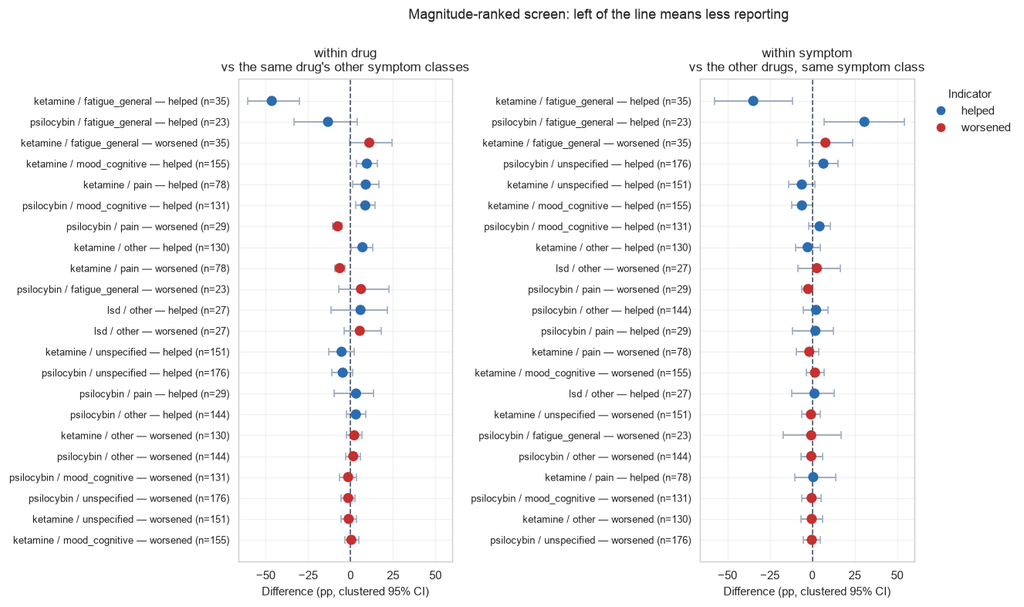

Patterns Worth Investigating

8 of 44 gated contrasts have a difference interval clear of zero without sitting at a boundary rate. The largest is ketamine / fatigue_general, where helped-reporting runs 46.4 percentage points below the same drug's other symptom classes (37.1% vs 83.5%; interval -60.4 to -30.1 pp; Cohen h=-1.00; n=35 rows from 35 reporter accounts). Read the sign: this is a deficit in reported benefit for that symptom class, not evidence of benefit. The remaining separated contrasts are ketamine / fatigue_general (helped, within symptom, -34.7 pp); psilocybin / fatigue_general (helped, within symptom, +30.7 pp); ketamine / mood_cognitive (helped, within drug, +9.6 pp); ketamine / pain (helped, within drug, +8.9 pp); psilocybin / mood_cognitive (helped, within drug, +8.7 pp); ketamine / other (helped, within drug, +7.0 pp); ketamine / pain (worsened, within drug, -6.3 pp). Each is an observational extraction signal worth human validation, not a causal or clinical conclusion, and 'interval clear of zero' is a description of the interval, not a significance test. Separately, psilocybin / pain (worsened 0% of 29 rows, within drug) sits at a boundary rate of 0% or 100%. Such an interval is set entirely by the comparison arm rather than by any variation of its own, so it is excluded from the ranking above rather than reported as a separated cell.

## 8. Reporting-signal tiers

These tiers prioritize patterns for validation, not treatments for patients. They are built from two ingredients and no test:

1. **Evidence volume** — a cell must clear the gate (≥20 rows, ≥10 reporter accounts) to be tiered at all; below that it is `Insufficient evidence`, whatever its point estimate looks like.
2. **Separation and direction** — where the **contrast's own** bootstrap interval sits relative to zero. The reference is the same drug's other symptom classes, so a tier moves one factor, and both arms are recomputed inside every resample of whole accounts.

The result is four labels: `Above the drug's other symptom classes`, `Below the drug's other symptom classes`, `Consistent with the drug's other symptom classes`, and `Insufficient evidence`. **A tier is never a quality judgement and never implies benefit** — a `Below` tier marks a cell where people report *less* improvement, which is exactly as interesting for validation and the opposite in clinical meaning.

Three things from earlier drafts are gone. A two-sided binomial p-value against the pooled rate promoted below-baseline cells to "Strong reporting signal" with no sign attached, and an `n ≥ 15 or p < 0.10` rule promoted a cell whose rate was not separated to "Moderate reporting signal" on sample size alone. The reporting-NNT-analog column is also removed: with no control arm there is no number needed to treat, and the column read as one while silently blanking for every below-baseline cell. Most recently, the tier compared a cell's *marginal* interval against a corpus rate treated as a known constant — which ignored the uncertainty in the comparator and the accounts shared between the two sides, and could hand a cell a stronger tier than the data support. Tiers now come from the contrast distribution itself.

| drug | symptom class | k | rows | reporter accounts | helped share | reference share | difference (pp) | diff low | diff high | Cohen h | tier |
| --- | --- | --- | --- | --- | --- | --- | --- | --- | --- | --- | --- |
| ketamine | mood_cognitive | 136 | 155 | 155 | 87.7% | 78.1% | +9.6 | +3.4 | +15.6 | +0.26 | Above the drug's other symptom classes |
| psilocybin | mood_cognitive | 122 | 131 | 131 | 93.1% | 84.5% | +8.7 | +3.0 | +14.3 | +0.28 | Above the drug's other symptom classes |
| ketamine | other | 112 | 130 | 130 | 86.2% | 79.1% | +7.0 | +0.5 | +13.3 | +0.19 | Above the drug's other symptom classes |
| ketamine | pain | 69 | 78 | 78 | 88.5% | 79.5% | +8.9 | +1.2 | +16.7 | +0.25 | Above the drug's other symptom classes |
| ketamine | fatigue_general | 13 | 35 | 35 | 37.1% | 83.5% | -46.4 | -60.4 | -30.1 | -1.00 | Below the drug's other symptom classes |
| psilocybin | unspecified | 147 | 176 | 176 | 83.5% | 88.1% | -4.6 | -11.1 | +1.4 | -0.13 | Consistent with the drug's other symptom classes |
| ketamine | unspecified | 116 | 151 | 151 | 76.8% | 82.1% | -5.3 | -12.8 | +2.3 | -0.13 | Consistent with the drug's other symptom classes |
| psilocybin | other | 128 | 144 | 144 | 88.9% | 85.8% | +3.1 | -2.5 | +8.8 | +0.09 | Consistent with the drug's other symptom classes |
| psilocybin | pain | 26 | 29 | 29 | 89.7% | 86.4% | +3.2 | -9.6 | +13.6 | +0.10 | Consistent with the drug's other symptom classes |
| lsd | other | 24 | 27 | 27 | 88.9% | 83.0% | +5.9 | -11.7 | +21.8 | +0.17 | Consistent with the drug's other symptom classes |
| psilocybin | fatigue_general | 17 | 23 | 23 | 73.9% | 87.2% | -13.3 | -33.3 | +4.2 | -0.34 | Consistent with the drug's other symptom classes |
| lsd | unspecified | 14 | 18 | 18 | 77.8% | 87.1% | -9.3 | -29.7 | +9.3 | -0.25 | Insufficient evidence |
| ketamine | low_energy | 11 | 16 | 16 | 68.8% | 81.1% | -12.3 | -36.6 | +9.8 | -0.29 | Insufficient evidence |
| psilocybin | low_energy | 12 | 16 | 16 | 75.0% | 87.0% | -12.0 | -35.5 | +9.7 | -0.31 | Insufficient evidence |
| lsd | mood_cognitive | 15 | 15 | 15 | 100.0% | 81.5% | +18.5 | +9.4 | +29.0 | +0.89 | Insufficient evidence |
| lsd | fatigue_general | 6 | 9 | 9 | 66.7% | 87.3% | -20.7 | -54.2 | +12.7 | -0.50 | Insufficient evidence |
| ketamine | pem_explicit | 7 | 9 | 9 | 77.8% | 80.8% | -3.0 | -35.9 | +21.0 | -0.07 | Insufficient evidence |
| psilocybin | pem_explicit | 5 | 9 | 9 | 55.6% | 87.1% | -31.6 | -65.9 | +2.0 | -0.73 | Insufficient evidence |
| lsd | low_energy | 4 | 5 | 5 | 80.0% | 85.3% | -5.3 | -52.0 | +21.2 | -0.14 | Insufficient evidence |
| lsd | pain | 3 | 4 | 4 | 75.0% | 85.5% | -10.5 | -81.4 | +20.4 | -0.27 | Insufficient evidence |
| ketamine | exertion_intolerance | 1 | 2 | 2 | 50.0% | 80.8% | -30.8 | -83.3 | +21.7 | -0.66 | Insufficient evidence |
| psilocybin | exertion_intolerance | 2 | 2 | 2 | 100.0% | 86.6% | +13.4 | +10.3 | +16.9 | +0.75 | Insufficient evidence |
| lsd | pem_explicit | 1 | 1 | 1 | 100.0% | 84.8% | +15.2 | +7.2 | +24.6 | +0.80 | Insufficient evidence |
| lsd | exertion_intolerance | 1 | 1 | 1 | 100.0% | 84.8% | +15.2 | +7.6 | +23.8 | +0.80 | Insufficient evidence |

**Tier summary.** Above the drug's other symptom classes: 4; Below the drug's other symptom classes: 1; Consistent with the drug's other symptom classes: 6; Insufficient evidence: 13. The below-reference cells are the ones to validate first, because a symptom class where people report less improvement is the claim most likely to be wrong in a way that matters.

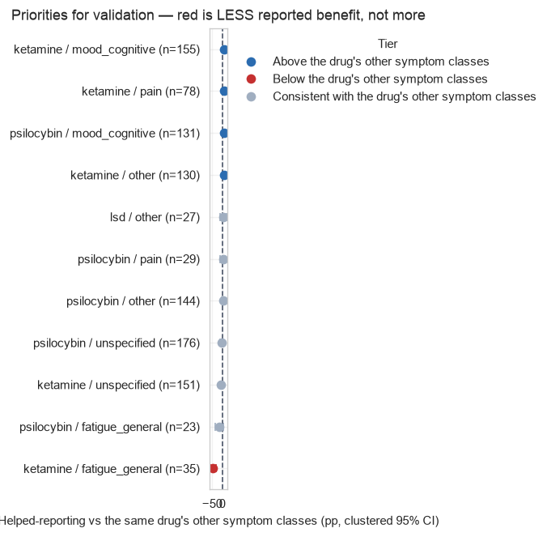

Cells below the evidence gate are omitted from this chart entirely (13 of 24), rather than plotted with an interval spanning most of the axis.

## 9. What patients are saying

This notebook cannot responsibly reproduce patient quotes: the v2 loader deliberately strips `source_window.text`, evidence quotes, author hashes, and free-text dose fields before data reach the analysis. The quantitative categories above are therefore the complete patient- experience evidence available to this privacy-safe notebook. A follow-up qualitative study would need a separately privacy-reviewed raw corpus, timestamps, source relationships, and manual quote redaction; it should not be reconstructed from this output.

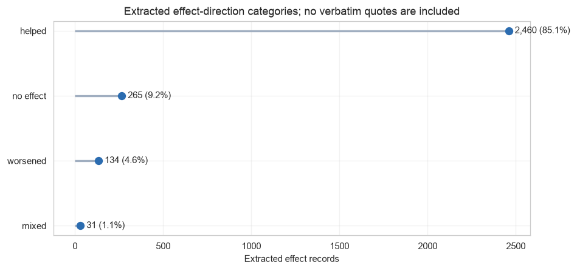

## 10. Conclusion

Among self-reported actual-use reporter-drug pairs in this v2 probe, the defensible answer is that experiences are heterogeneous and **symptom-specific in a direction that matters**. Helped directions dominate overall — roughly six in seven effect-bearing pairs report at least one. Across the three drugs the any-helped shares are close together and their intervals overlap; because **no equivalence margin was prespecified and no equivalence test was performed**, that is reported here as a set of descriptive estimates with overlapping uncertainty and **not** as evidence that the drugs perform alike. The per-drug any-helped shares and their intervals are in notebook 2, §1.1 for the reader to judge; an overlap is a statement about precision, not about sameness.

The one pattern that separates is a deficit rather than a benefit, and it is about **nonspecific fatigue**: holding the drug fixed, helped-reporting for the general-fatigue class falls well below ketamine's other symptom classes, and holding the symptom class fixed, ketamine falls below the other drugs within it. Two contrasts moving different factors agree in sign, and a reporter-clustered interaction model puts the general-fatigue main effect clearly below zero while leaving the ketamine-specific increment imprecise — so the better-supported statement is that *fatigue attracts less reported benefit*, with ketamine the sharpest case rather than a separate finding. Mood/cognitive runs the other way, above the other classes for psilocybin.

**This is deliberately not a PEM result.** Post-exertional malaise is a specific delayed worsening after exertion and is the outcome a post-viral cohort most wants an answer about, but targets that actually state it are rare here: every explicit-PEM cell falls below the evidence gate for every drug, and none is estimated. An earlier version of this notebook reported the deficit as an energy/PEM finding because one regular expression put explicit PEM, exertion intolerance, ordinary fatigue and low energy in a single class. Separated, that class is mostly ordinary fatigue. The finding above is worth validating; it is not evidence about PEM.

Alongside that, no-effect, worsened, and mixed/conflicting profiles coexist throughout: benefit-plus-harm pairs are a substantive outcome and are not collapsed into treatment success. Adverse-event records coexist with both helped and worsened profiles, and any-event shares vary by drug. Ketamine's stated routes are majority IV/IM, and injected use plausibly travels with a different reporting context than oral self-administration — but **this run records no administration-setting field**, so that remains an untested explanation rather than a finding, and no difference in this notebook is attributed to supervision.

The main practical constraint is coverage. Only 9.1% of effect records state a duration, and numeric amount-plus-unit records are sparse and not commensurable across drugs. Linking each dose to outcomes extracted from **its own claim** — rather than to its reporter's overall outcome summary — leaves psilocybin in grams as the only subset thick enough to bin; **ketamine in milligrams and LSD are both reported as insufficient data**. Within psilocybin the binned reporting rates are close to flat across ≤1 g, 1–3 g, and >3 g, and no dose-response relationship is estimated or implied. Route is reported for ketamine only, as a stated route. Sensitivity checks on high-confidence records, prolific pairs, and single-target-drug reporters indicate how much these summaries depend on extraction and reporter composition — not whether any drug is effective.

These results support a narrow position: symptom-specific, harm-aware, direction-aware extraction is more informative than a single positive label, and the general-fatigue deficit is the pattern to human-validate first — starting with whether the extractor's fatigue targets mean what the class name says. This notebook reports no p-values, tests no hypotheses, and cannot support a reporter-specific treatment recommendation.

## 11. Research limitations

- **Selection bias:** the cohort consists of people whose Reddit reports were already associated with the target drugs; people who tried a drug and never posted are absent.
- **Reporting bias:** posting is not independent of outcome, and positive or adverse experiences may be disproportionately narrated.
- **Survivorship bias:** persistent users and people who continue participating can be overrepresented relative to people who stopped posting.
- **Recall bias:** extracted reports may summarize remembered experiences rather than records collected prospectively.
- **Confounding:** indication, illness severity, clinical supervision, co-treatments, dose, route, and access differ across drugs and are not controlled. Ketamine's majority IV/IM stated route is the clearest instance and is not adjusted for anywhere.
- **Setting is unmeasured:** this run records no structured administration-setting or supervision field. Route is not a proxy for one — intranasal esketamine is routinely supervised, and an injection label documents no supervision — so no result here is explained by clinic versus take-home administration.
- **Symptom classes are regular expressions over free text, not adjudicated codes:** a class says which words the target contained, not what the reporter meant. `pem_explicit` requires post-exertional language, but no human has checked whether those targets really describe post-exertional malaise, nor whether `fatigue_general` targets exclude it — the class precision is **unestimated**, because the targets themselves are quote-bearing text this notebook may not display. The consequence runs both ways: the fatigue deficit could be diluted PEM, and the absent PEM cells could be under-counted. Both need item-level validation against the source passages, which is the first thing to do with this result.
- **Identity:** an analysis unit is a Reddit account, not a verified person. Shared accounts, one person using several accounts, and misattributed self-reports are all possible and unmeasured, so account counts are an upper bound on distinct people and the clustering correction is only as good as the account-to-person mapping.
- **No equivalence testing:** where intervals for two drugs overlap, that is reported as overlapping uncertainty. No equivalence margin was prespecified and no equivalence test was run, so nothing here shows that two drugs perform alike.
- **No control group:** no untreated or comparator arm exists, so rates are not causal effects. For the same reason no number needed to treat is reported — an earlier draft carried a "reporting NNT analog" column, which has been removed rather than caveated.
- **Extraction labels are not clinical outcomes:** a `helped` or `worsened` label is the model's reading of a passage, not a validated outcome measure. No item-level validation of *this* extraction exists (see the validation-gate bullet), so the direction of any label bias in this run is **unmeasured**. An earlier draft asserted that positive labels are over-called by 10–20%; that figure has no source in this repository and has been removed.
- **Extraction instability:** the v1 corpus documentation reports 36.5% field-set and 58.8% value agreement across two identical passes. That measurement was made on **v1's extraction of community-scored triples, not on this pipeline**, and no repeat-pass check was run here. It is carried as an order-of-magnitude warning about record-level stability, not as a measurement of this run — which means every interval in this notebook covers sampling only and understates total error.
- **Attribution:** this run extracts one claim per passage per target drug with a quote for each field, so v1's collective-outcome problem — one outcome in a post listing several drugs being attached to all of them — does not apply in the same form. Drug misattribution within a stack remains possible and is unmeasured; the single-target-drug sensitivity check in §6 is the only probe of it here.
- **Temporal snapshot:** this is one source snapshot and one extraction run, not a longitudinal follow-up. The snapshot date is the date in the snapshot's name; post timestamps are not loaded, so **the period the content was written in is unknown**. Treatment switching over time cannot be reconstructed, and no dose-response over time is estimable.
- **Missingness:** `not stated` is silence, not absence. Duration (91% unstated), numeric amount, route, intent, formulation, schedule, and context have uneven coverage. Once doses are linked to outcomes from their own claim, both LSD and ketamine numeric dosing are reported as insufficient rather than estimated, and route is reported for ketamine only.
- **Clustering:** claims and records are concentrated among reporters. Intervals here resample whole reporter accounts, which handles the dependence between arms of a comparison, but it does not remove the influence of a prolific reporter on a point estimate.
- **No hypothesis tests:** this notebook reports no p-values, chi-squared statistics, or false-discovery-rate adjustments. Comparisons are differences with clustered intervals ranked by magnitude. "Interval clear of zero" is a description of an interval, not a test decision, and none of the screens in §7 or §8 should be read as confirmatory.
- **Validation gate:** the prior v2 report states that human item-level validation was skipped. Mechanical quote grounding does not prove correct field attribution, drug attribution, or actual-use classification. The observed patterns are unvalidated.
- **Privacy boundary:** no verbatim quotes or author identifiers were carried into this notebook. A public release would require an explicit redaction review even if quotes were later added.

The database is a quote-bearing research artifact, while this notebook is a quote-free aggregation. Its provenance block below records the exact data snapshot used to produce the HTML export.

| item | value |
| --- | --- |
| database | psychedelic_pharmacology.db |
| database SHA-256 | 2edbe6136ec8c451e486ecd3d3b19cbdf1ed2e78e47a07c5a808f8cf137f96cc |
| run ID (pinned) | 710567555e22b68c025d8ceb1c3373564d7f9b01dcc5fe94b02b7c3209ecbc05 |
| run created | 2026-08-09T22:30:11.041289+00:00 |
| model | deepseek/deepseek-v4-flash |
| provider / base URL | openai / https://openrouter.ai/api |
| sampling | temperature 0.0, max_tokens 32,768, reasoning_effort high |
| source snapshot | reddit_2026-06-13.db (source snapshot documented by the v2 run) |
| source snapshot date | 2026-06-13 (the date in the snapshot name) |
| content date range | unavailable — post timestamps are not loaded |
| execution date (UTC) | 2026-08-10 |
| loader | studies/psychedelics/v2/psychedelics_v2.py |
| inference | no p-values; reporter-clustered bootstrap intervals only |
| bootstrap | 2,000 resamples of whole reporter accounts, base seed 20260809 |
| evidence gate | ≥20 rows and ≥10 reporter accounts |
| skill version | research-assistant v2 |

**Final interpretation:** These findings should be used to prioritize validation questions and improve patient-experience measurement, not to select or reject a treatment for an individual.

These findings reflect reporting patterns in online communities, not population-level treatment effects. This is not medical advice.